# Week-2-Day-2-Regression and Diagnostic Test

[figure not shown]

## **Regression and Correlational Analysis**

### **Regression Analysis**

Regression analysis is a statistical technique used to examine the relationship between one or more independent variables (predictors) and a dependent variable (outcome). It helps to understand how changes in the independent variables are associated with changes in the dependent variable. Regression analysis can be used for prediction, forecasting, and identifying important factors that influence the outcome.

#### **History of Regression Analysis**

The term "regression" was first introduced by Sir Francis Galton in the late 1800s when he observed that the heights of children tended to regress toward the mean height of their parents. Karl Pearson and Ronald Fisher further contributed to the development of regression techniques in the early 20th century, leading to its widespread use in economics, social sciences, and natural sciences.

### **Correlation Analysis**

Correlation analysis measures the strength and direction of the relationship between two variables. **Correlation does not imply causation**; it only indicates the presence and strength of a relationship.

### **Load the Following Libraries**

```python
import pandas as pd
import numpy as np
import matplotlib.pyplot as plt
import seaborn as sns
import scipy.stats as stats
import statsmodels.api as sm
import statsmodels.formula.api as smf
from statsmodels.stats.outliers_influence import variance_inflation_factor
from statsmodels.stats.diagnostic import het_breuschpagan
from statsmodels.stats.stattools import durbin_watson
import warnings
```

### **Filter Warnings and Set the Visualization Theme**

```python
warnings.filterwarnings('ignore')
sns.set_theme(style="whitegrid")
pd.set_option('display.float_format', '{:.4f}'.format) # Equivalent to R's options(scipen=999)

print("Libraries loaded successfully.")
```

```
Libraries loaded successfully.
```

### **1. Explore the Dataset (`mtcars`)**

The `mtcars` data was extracted from the 1974 Motor Trend US magazine, comprising fuel consumption and 10 aspects of automobile design and performance for 32 automobiles.

### **Load mtcars dataset from Rdatasets repository**

```python
url_mtcars = "https://raw.githubusercontent.com/vincentarelbundock/Rdatasets/master/csv/datasets/mtcars.csv"
mtcars = pd.read_csv(url_mtcars, index_col=0)
```

#### **Equivalent to R's head() and str()**

```python
print("--- First 6 Rows ---")
display(mtcars.head(6))
```

```
--- First 6 Rows ---
```

| rownames | mpg | cyl | disp | hp | drat | wt | qsec | vs | am | gear | carb |
| --- | --- | --- | --- | --- | --- | --- | --- | --- | --- | --- | --- |
| Mazda RX4 | 21.0000 | 6 | 160.0000 | 110 | 3.9000 | 2.6200 | 16.4600 | 0 | 1 | 4 | 4 |
| Mazda RX4 Wag | 21.0000 | 6 | 160.0000 | 110 | 3.9000 | 2.8750 | 17.0200 | 0 | 1 | 4 | 4 |
| Datsun 710 | 22.8000 | 4 | 108.0000 | 93 | 3.8500 | 2.3200 | 18.6100 | 1 | 1 | 4 | 1 |
| Hornet 4 Drive | 21.4000 | 6 | 258.0000 | 110 | 3.0800 | 3.2150 | 19.4400 | 1 | 0 | 3 | 1 |
| Hornet Sportabout | 18.7000 | 8 | 360.0000 | 175 | 3.1500 | 3.4400 | 17.0200 | 0 | 0 | 3 | 2 |
| Valiant | 18.1000 | 6 | 225.0000 | 105 | 2.7600 | 3.4600 | 20.2200 | 1 | 0 | 3 | 1 |

```python
print("\n--- Data Structure & Info ---")
mtcars.info()
```

```
--- Data Structure & Info ---
<class 'pandas.core.frame.DataFrame'>
Index: 32 entries, Mazda RX4 to Volvo 142E
Data columns (total 11 columns):
 #   Column  Non-Null Count  Dtype
---  ------  --------------  -----
 0   mpg     32 non-null     float64
 1   cyl     32 non-null     int64
 2   disp    32 non-null     float64
 3   hp      32 non-null     int64
 4   drat    32 non-null     float64
 5   wt      32 non-null     float64
 6   qsec    32 non-null     float64
 7   vs      32 non-null     int64
 8   am      32 non-null     int64
 9   gear    32 non-null     int64
 10  carb    32 non-null     int64
dtypes: float64(5), int64(6)
memory usage: 3.0+ KB
```

### **Scatter Plots are Essential Before Regression and Correlation**

**Note:** There is a strong negative correlation between weight and miles per gallon. As the weight of the car increases, the miles per gallon decreases.

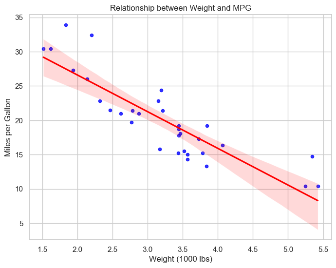

```python
plt.figure(figsize=(8, 6))
sns.regplot(x='wt', y='mpg', data=mtcars,
            scatter_kws={'color': 'blue', 's': 20},
            line_kws={'color': 'red'})
plt.title("Relationship between Weight and MPG")
plt.xlabel("Weight (1000 lbs)")
plt.ylabel("Miles per Gallon")
plt.show()
```

### **Compute Pearson & Spearman Correlation Analysis**

**Hypotheses:**

- **H0:** There is no significant correlation between weight and miles per gallon ($r = 0$).
- **H1:** There is a significant correlation between weight and miles per gallon ($r \neq 0$).

**Decision Rule:** If the p-value < 0.05, we reject the null hypothesis.

### **Pearson Correlation**

```python
r_pearson, p_pearson = stats.pearsonr(mtcars['wt'], mtcars['mpg'])
print(f"Pearson r: {r_pearson:.5f}, p-value: {p_pearson:.2e}")
```

```
Pearson r: -0.86766, p-value: 1.29e-10
```

### **Spearman Correlation (Non-parametric, used when normality is violated or data is ordinal)**

```python
r_spearman, p_spearman = stats.spearmanr(mtcars['wt'], mtcars['mpg'])
print(f"Spearman rho: {r_spearman:.5f}, p-value: {p_spearman:.2e}")
```

```
Spearman rho: -0.88642, p-value: 1.49e-11
```

### **Correlation and Covariance Matrices**

Examine relationships between multiple variables simultaneously.

```python
num_vars = mtcars[['mpg', 'cyl', 'disp', 'hp', 'wt']]
```

```python
# Correlation Matrix
corr_matrix = num_vars.corr(method='pearson')
print("--- Correlation Matrix ---")
display(corr_matrix.round(2))
```

```
--- Correlation Matrix ---
```

|  | mpg | cyl | disp | hp | wt |
| --- | --- | --- | --- | --- | --- |
| mpg | 1.0000 | -0.8500 | -0.8500 | -0.7800 | -0.8700 |
| cyl | -0.8500 | 1.0000 | 0.9000 | 0.8300 | 0.7800 |
| disp | -0.8500 | 0.9000 | 1.0000 | 0.7900 | 0.8900 |
| hp | -0.7800 | 0.8300 | 0.7900 | 1.0000 | 0.6600 |
| wt | -0.8700 | 0.7800 | 0.8900 | 0.6600 | 1.0000 |

### **Covariance Matrix**

```python
cov_matrix = num_vars.cov()
display(cov_matrix.round(2))
```

|  | mpg | cyl | disp | hp | wt |
| --- | --- | --- | --- | --- | --- |
| mpg | 36.3200 | -9.1700 | -633.1000 | -320.7300 | -5.1200 |
| cyl | -9.1700 | 3.1900 | 199.6600 | 101.9300 | 1.3700 |
| disp | -633.1000 | 199.6600 | 15360.8000 | 6721.1600 | 107.6800 |
| hp | -320.7300 | 101.9300 | 6721.1600 | 4700.8700 | 44.1900 |
| wt | -5.1200 | 1.3700 | 107.6800 | 44.1900 | 0.9600 |

### **Visualize Correlation Matrix (Equivalent to R's corrplot)**

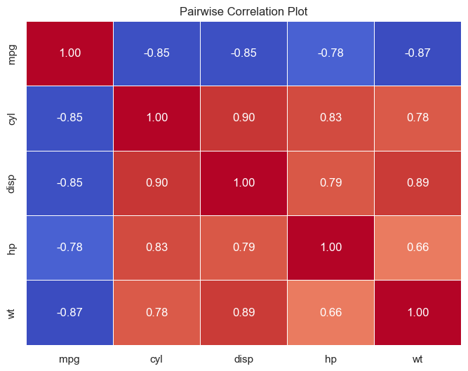

```python
plt.figure(figsize=(8, 6))
sns.heatmap(corr_matrix, annot=True,
            cmap='coolwarm',
            fmt=".2f",
            linewidths=.5,
            cbar=False)
plt.title("Pairwise Correlation Plot")
plt.show()
```

### **2. Simple Linear Regression (SLR) - `mtcars`**

**Equation:** $\hat{MPG} = 37.2851 - 5.3445 \times wt$

**Interpretation:** For every 1 unit increase in weight (1000 lbs), the MPG decreases by ~5.344 units.

#### **Fit Simple Linear Regression**

```python
model_slr = smf.ols('mpg ~ wt', data=mtcars).fit()
print(model_slr.summary())
```

```
                            OLS Regression Results
==============================================================================
Dep. Variable:                    mpg   R-squared:                       0.753
Model:                            OLS   Adj. R-squared:                  0.745
Method:                 Least Squares   F-statistic:                     91.38
Date:                Tue, 18 Aug 2026   Prob (F-statistic):           1.29e-10
Time:                        15:11:48   Log-Likelihood:                -80.015
No. Observations:                  32   AIC:                             164.0
Df Residuals:                      30   BIC:                             167.0
Df Model:                           1
Covariance Type:            nonrobust
==============================================================================
                 coef    std err          t      P>|t|      [0.025      0.975]
------------------------------------------------------------------------------
Intercept     37.2851      1.878     19.858      0.000      33.450      41.120
wt            -5.3445      0.559     -9.559      0.000      -6.486      -4.203
==============================================================================
Omnibus:                        2.988   Durbin-Watson:                   1.252
Prob(Omnibus):                  0.225   Jarque-Bera (JB):                2.399
Skew:                           0.668   Prob(JB):                        0.301
Kurtosis:                       2.877   Cond. No.                         12.7
==============================================================================

Notes:
[1] Standard Errors assume that the covariance matrix of the errors is correctly specified.
```

### **Confidence Intervals for Coefficients**

```python
print("\n--- 95% Confidence Intervals ---")
display(model_slr.conf_int(alpha=0.05))
```

```
--- 95% Confidence Intervals ---
```

|  | 0 | 1 |
| --- | --- | --- |
| Intercept | 33.4505 | 41.1198 |
| wt | -6.4863 | -4.2026 |

### **Prediction for a new car (wt = 3.5)**

```python
new_car = pd.DataFrame({'wt': [3.5]})
pred_slr = model_slr.get_prediction(new_car).summary_frame(alpha=0.05)
```

```python
print("\n--- Predictions for wt=3.5 ---")
# mean_ci is Confidence Interval, obs_ci is Prediction Interval
display(pred_slr[['mean', 'mean_ci_lower', 'mean_ci_upper', 'obs_ci_lower', 'obs_ci_upper']])
```

```
--- Predictions for wt=3.5 ---
```

|  | mean | mean_ci_lower | mean_ci_upper | obs_ci_lower | obs_ci_upper |
| --- | --- | --- | --- | --- | --- |
| 0 | 18.5795 | 17.4334 | 19.7255 | 12.2543 | 24.9047 |

### **3. Hypertension Data (SLR with Missing Data Handling)**

We will load `htn_dat.csv`, check for missing values, perform complete case analysis (drop NA), and model SBP ~ BMI.

```
--- Missing Values Summary ---
```

```
BMI                    670
married                164
hgb_centered          1394
adv_HIV               1961
log_creat_centered    1538
dtype: int64
```

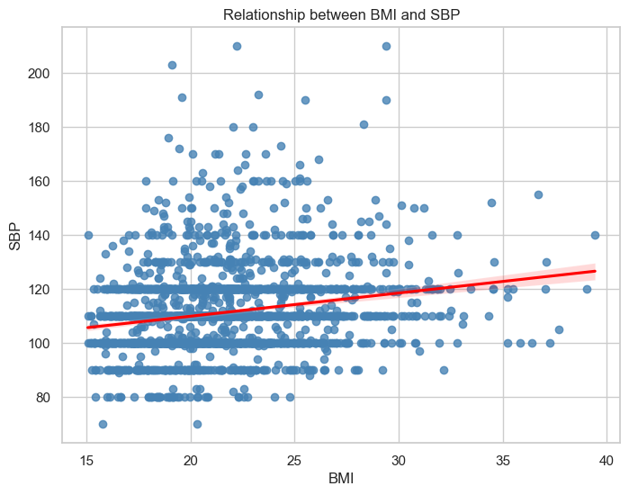

```
                            OLS Regression Results
==============================================================================
Dep. Variable:                    SBP   R-squared:                       0.041
Model:                            OLS   Adj. R-squared:                  0.041
Method:                 Least Squares   F-statistic:                     100.2
Date:                Tue, 18 Aug 2026   Prob (F-statistic):           3.96e-23
Time:                        15:14:31   Log-Likelihood:                -9623.3
No. Observations:                2326   AIC:                         1.925e+04
Df Residuals:                    2324   BIC:                         1.926e+04
Df Model:                           1
Covariance Type:            nonrobust
==============================================================================
                 coef    std err          t      P>|t|      [0.025      0.975]
------------------------------------------------------------------------------
Intercept     92.8415      1.872     49.587      0.000      89.170      96.513
BMI            0.8572      0.086     10.012      0.000       0.689       1.025
==============================================================================
Omnibus:                      641.236   Durbin-Watson:                   2.060
Prob(Omnibus):                  0.000   Jarque-Bera (JB):             2483.156
Skew:                           1.306   Prob(JB):                         0.00
Kurtosis:                       7.336   Cond. No.                         131.
==============================================================================

Notes:
[1] Standard Errors assume that the covariance matrix of the errors is correctly specified.

Prediction for BMI = 24.4898:
```

|  | mean | mean_ci_lower | mean_ci_upper | obs_ci_lower | obs_ci_upper |
| --- | --- | --- | --- | --- | --- |
| 0 | 113.8334 | 113.0444 | 114.6223 | 84.0918 | 143.5749 |

```python
try:
    htn = pd.read_csv("htn_dat.csv")
    print("--- Missing Values Summary ---")
    missing_vals = htn.isnull().sum()
    display(missing_vals[missing_vals > 0]) # Show only columns with missing values

    # Complete case analysis
    comp_data = htn.dropna()

    # Scatter plot
    plt.figure(figsize=(8, 6))
    sns.regplot(x='BMI', y='SBP', data=comp_data,
                scatter_kws={'color': 'steelblue'},
                line_kws={'color': 'red'})
    plt.title("Relationship between BMI and SBP")
    plt.show()

    # SLR Model
    model_htn = smf.ols('SBP ~ BMI', data=comp_data).fit()
    print(model_htn.summary())

    # Predict for new patient: Weight=75kg, Height=1.75m
    bmi_new = 75 / (1.75**2)
    new_person = pd.DataFrame({'BMI': [bmi_new]})
    pred_htn = model_htn.get_prediction(new_person).summary_frame(alpha=0.05)
    print(f"\nPrediction for BMI = {bmi_new:.4f}:")
    display(pred_htn[['mean', 'mean_ci_lower', 'mean_ci_upper', 'obs_ci_lower', 'obs_ci_upper']])

except FileNotFoundError:
    print("[Note] 'htn_dat.csv' not found in directory. Skipping Hypertension section.")
```

### **4. Multiple Linear Regression (MLR)**

**Predictors:** `wt` and `hp` | **Outcome:** `mpg` **Equation:** $\hat{MPG} = 37.227 - 3.877(wt) - 0.031(hp)$

```python
model_mlr = smf.ols('mpg ~ wt + hp', data=mtcars).fit()
print(model_mlr.summary())
```

```
                            OLS Regression Results
==============================================================================
Dep. Variable:                    mpg   R-squared:                       0.827
Model:                            OLS   Adj. R-squared:                  0.815
Method:                 Least Squares   F-statistic:                     69.21
Date:                Tue, 18 Aug 2026   Prob (F-statistic):           9.11e-12
Time:                        15:15:40   Log-Likelihood:                -74.326
No. Observations:                  32   AIC:                             154.7
Df Residuals:                      29   BIC:                             159.0
Df Model:                           2
Covariance Type:            nonrobust
==============================================================================
                 coef    std err          t      P>|t|      [0.025      0.975]
------------------------------------------------------------------------------
Intercept     37.2273      1.599     23.285      0.000      33.957      40.497
wt            -3.8778      0.633     -6.129      0.000      -5.172      -2.584
hp            -0.0318      0.009     -3.519      0.001      -0.050      -0.013
==============================================================================
Omnibus:                        5.303   Durbin-Watson:                   1.362
Prob(Omnibus):                  0.071   Jarque-Bera (JB):                4.046
Skew:                           0.855   Prob(JB):                        0.132
Kurtosis:                       3.332   Cond. No.                         588.
==============================================================================

Notes:
[1] Standard Errors assume that the covariance matrix of the errors is correctly specified.
```

### **Model Diagnostics: Multicollinearity & Influential Observations**

- **VIF (Variance Inflation Factor):** Values > 5 or 10 indicate high multicollinearity.
- **Cook's Distance:** Identifies influential observations. Threshold commonly set at $4/n$.

#### **1. Multicollinearity (VIF)**

```python
X_vif = mtcars[['wt', 'hp']].copy()
X_vif['const'] = 1 # VIF requires the constant term
vif_data = pd.DataFrame()
vif_data["feature"] = X_vif.columns
vif_data["VIF"] = [variance_inflation_factor(X_vif.values, i) for i in range(X_vif.shape[1])]
print("--- VIF Values ---")
display(vif_data)
```

```
--- VIF Values ---
```

|  | feature | VIF |
| --- | --- | --- |
| 0 | wt | 1.7666 |
| 1 | hp | 1.7666 |
| 2 | const | 12.1615 |

#### **2. Cook's Distance & Influential Observations**

```python
influence = model_mlr.get_influence()
cooks_d = influence.cooks_distance[0]
mtcars['cooks_d'] = cooks_d
threshold = 4 / len(mtcars)
influential_obs = mtcars[mtcars['cooks_d'] > threshold].index
print(f"\nInfluential observations (Cook's D > {threshold:.3f}): {influential_obs.tolist()}")
```

```
Influential observations (Cook's D > 0.125): ['Chrysler Imperial', 'Fiat 128', 'Toyota Corolla', 'Maserati Bora']
```

#### **3. Refit without influential observations**

```python
mtcars_no_inf = mtcars.drop(influential_obs)
model_mlr_no_inf = smf.ols('mpg ~ wt + hp', data=mtcars_no_inf).fit()
print("\n--- MLR Model Summary (No Influential Obs) ---")
print(model_mlr_no_inf.summary())
```

```
--- MLR Model Summary (No Influential Obs) ---
                            OLS Regression Results
==============================================================================
Dep. Variable:                    mpg   R-squared:                       0.892
Model:                            OLS   Adj. R-squared:                  0.883
Method:                 Least Squares   F-statistic:                     102.9
Date:                Tue, 18 Aug 2026   Prob (F-statistic):           8.60e-13
Time:                        15:18:50   Log-Likelihood:                -54.076
No. Observations:                  28   AIC:                             114.2
Df Residuals:                      25   BIC:                             118.1
Df Model:                           2
Covariance Type:            nonrobust
==============================================================================
                 coef    std err          t      P>|t|      [0.025      0.975]
------------------------------------------------------------------------------
Intercept     36.3375      1.255     28.956      0.000      33.753      38.922
wt            -3.7517      0.501     -7.485      0.000      -4.784      -2.719
hp            -0.0332      0.008     -4.227      0.000      -0.049      -0.017
==============================================================================
Omnibus:                        0.259   Durbin-Watson:                   1.417
Prob(Omnibus):                  0.879   Jarque-Bera (JB):                0.450
Skew:                           0.079   Prob(JB):                        0.799
Kurtosis:                       2.400   Cond. No.                         601.
==============================================================================

Notes:
[1] Standard Errors assume that the covariance matrix of the errors is correctly specified.
```

### **Inferential Tests for Assumptions**

1. **Normality:** Shapiro-Wilk & Anderson-Darling tests.
2. **Homoscedasticity:** Breusch-Pagan test.
3. **Independence:** Durbin-Watson test.

```python
residuals = model_mlr.resid
```

#### **1. Normality Tests**

```python
stat_sw, p_sw = stats.shapiro(residuals)
print(f"Shapiro-Wilk Test: W={stat_sw:.5f}, p-value={p_sw:.5f}")

stat_ad, crit_ad, sig_ad = stats.anderson(residuals, dist='norm')
print(f"Anderson-Darling Statistic: {stat_ad:.5f}")
```

```
Shapiro-Wilk Test: W=0.92792, p-value=0.03427
Anderson-Darling Statistic: 0.66581
```

#### **Q-Q Plot & Histogram**

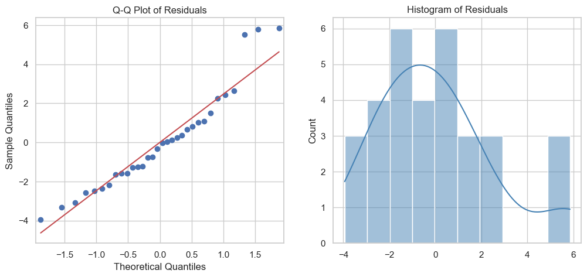

```python
fig, ax = plt.subplots(1, 2, figsize=(12, 5))
sm.qqplot(residuals, line='s', ax=ax[0])
ax[0].set_title("Q-Q Plot of Residuals")
sns.histplot(residuals, bins=10, kde=True, ax=ax[1], color='steelblue')
ax[1].set_title("Histogram of Residuals")
plt.show()
```

#### **2. Homoscedasticity (Breusch-Pagan)**

```python
bp_test = het_breuschpagan(residuals, model_mlr.model.exog)
print(f"\nBreusch-Pagan Test: BP={bp_test[0]:.5f}, p-value={bp_test[1]:.5f}")
```

```
Breusch-Pagan Test: BP=0.88072, p-value=0.64380
```

#### **3. Independence (Durbin-Watson)**

```python
dw_stat = durbin_watson(residuals)
print(f"Durbin-Watson Statistic: {dw_stat:.5f}")
```

```
Durbin-Watson Statistic: 1.36240
```

### **5. Macroeconomic Variables (Elasticities / Log-Log Model)**

Using the `economics` dataset. We will estimate a standard MLR and a Log-Log MLR to compute marginal elasticities.

```python
url_econ = "https://raw.githubusercontent.com/vincentarelbundock/Rdatasets/master/csv/ggplot2/economics.csv"
economics = pd.read_csv(url_econ)
economics.head()
```

|  | rownames | date | pce | pop | psavert | uempmed | unemploy |
| --- | --- | --- | --- | --- | --- | --- | --- |
| 0 | 1 | 1967-07-01 | 506.7000 | 198712.0000 | 12.6000 | 4.5000 | 2944 |
| 1 | 2 | 1967-08-01 | 509.8000 | 198911.0000 | 12.6000 | 4.7000 | 2945 |
| 2 | 3 | 1967-09-01 | 515.6000 | 199113.0000 | 11.9000 | 4.6000 | 2958 |
| 3 | 4 | 1967-10-01 | 512.2000 | 199311.0000 | 12.9000 | 4.9000 | 3143 |
| 4 | 5 | 1967-11-01 | 517.4000 | 199498.0000 | 12.8000 | 4.7000 | 3066 |

#### **Standard MLR**

```python
model_econ = smf.ols('psavert ~ pce + unemploy + pop + uempmed', data=economics).fit()
print("--- Macroeconomics Standard MLR Summary ---")
print(model_econ.summary())
```

```
--- Macroeconomics Standard MLR Summary ---
                            OLS Regression Results
==============================================================================
Dep. Variable:                psavert   R-squared:                       0.841
Model:                            OLS   Adj. R-squared:                  0.840
Method:                 Least Squares   F-statistic:                     752.1
Date:                Tue, 18 Aug 2026   Prob (F-statistic):          1.67e-225
Time:                        15:36:59   Log-Likelihood:                -910.03
No. Observations:                 574   AIC:                             1830.
Df Residuals:                     569   BIC:                             1852.
Df Model:                           4
Covariance Type:            nonrobust
==============================================================================
                 coef    std err          t      P>|t|      [0.025      0.975]
------------------------------------------------------------------------------
Intercept     45.6701      2.231     20.469      0.000      41.288      50.052
pce            0.0009      0.000      7.170      0.000       0.001       0.001
unemploy       0.0002   4.82e-05      5.182      0.000       0.000       0.000
pop           -0.0002    1.1e-05    -15.742      0.000      -0.000      -0.000
uempmed        0.1660      0.036      4.664      0.000       0.096       0.236
==============================================================================
Omnibus:                       27.089   Durbin-Watson:                   0.410
Prob(Omnibus):                  0.000   Jarque-Bera (JB):               47.117
Skew:                           0.329   Prob(JB):                     5.87e-11
Kurtosis:                       4.240   Cond. No.                     1.17e+07
==============================================================================

Notes:
[1] Standard Errors assume that the covariance matrix of the errors is correctly specified.
[2] The condition number is large, 1.17e+07. This might indicate that there are
strong multicollinearity or other numerical problems.
```

#### **Log-Log Model (Elasticities)**

```python
model_econ_log = smf.ols('np.log(psavert) ~ np.log(pce) + np.log(unemploy) + np.log(pop) + np.log(uempmed)', data=economics).fit()
print("\n--- Log-Log Macroeconomics MLR Summary ---")
print(model_econ_log.summary())
```

```
--- Log-Log Macroeconomics MLR Summary ---
                            OLS Regression Results
==============================================================================
Dep. Variable:        np.log(psavert)   R-squared:                       0.802
Model:                            OLS   Adj. R-squared:                  0.801
Method:                 Least Squares   F-statistic:                     575.9
Date:                Tue, 18 Aug 2026   Prob (F-statistic):          2.06e-198
Time:                        15:37:24   Log-Likelihood:                 204.39
No. Observations:                 574   AIC:                            -398.8
Df Residuals:                     569   BIC:                            -377.0
Df Model:                           4
Covariance Type:            nonrobust
====================================================================================
                       coef    std err          t      P>|t|      [0.025      0.975]
------------------------------------------------------------------------------------
Intercept           11.0113      6.795      1.621      0.106      -2.335      24.357
np.log(pce)         -0.3612      0.084     -4.291      0.000      -0.526      -0.196
np.log(unemploy)     0.4089      0.065      6.305      0.000       0.282       0.536
np.log(pop)         -0.8013      0.572     -1.401      0.162      -1.925       0.322
np.log(uempmed)      0.1619      0.066      2.448      0.015       0.032       0.292
==============================================================================
Omnibus:                       54.971   Durbin-Watson:                   0.388
Prob(Omnibus):                  0.000   Jarque-Bera (JB):              170.940
Skew:                          -0.425   Prob(JB):                     7.60e-38
Kurtosis:                       5.535   Cond. No.                     1.68e+04
==============================================================================

Notes:
[1] Standard Errors assume that the covariance matrix of the errors is correctly specified.
[2] The condition number is large, 1.68e+04. This might indicate that there are
strong multicollinearity or other numerical problems.
```

#### **Diagnostics for Log-Log**

```python
resid_log = model_econ_log.resid
stat_sw_log, p_sw_log = stats.shapiro(resid_log)
print(f"\nShapiro-Wilk Test (Log-Log): W={stat_sw_log:.5f}, p-value={p_sw_log:.5f}")

bp_test_log = het_breuschpagan(resid_log, model_econ_log.model.exog)
print(f"Breusch-Pagan Test (Log-Log): BP={bp_test_log[0]:.5f}, p-value={bp_test_log[1]:.5f}")
```

```
Shapiro-Wilk Test (Log-Log): W=0.96678, p-value=0.00000
Breusch-Pagan Test (Log-Log): BP=71.28804, p-value=0.00000
```

### **6. Additional Macro Example (CPI & Elasticities)**

Modeling Consumer Price Index (CPI) against Exchange Rates and Lending Interest Rates.

**Log-Log Equation:** $\ln(CPI) = -0.7043 + 1.5149\ln(ExchRate) - 0.5520\ln(LendIntRates)$

```python
try:
    df_macro = pd.read_csv("training model.csv")

    # Standard MLR
    model_cpi = smf.ols('CPI ~ ExchRate + LendIntRates', data=df_macro).fit()
    print("--- CPI MLR Summary ---")
    print(model_cpi.summary())

    # Cook's Distance & Refit
    inf_cpi = model_cpi.get_influence()
    cooks_d_cpi = inf_cpi.cooks_distance[0]
    df_macro['cooks_d'] = cooks_d_cpi
    thresh_cpi = 4 / len(df_macro)
    inf_obs_cpi = df_macro[df_macro['cooks_d'] > thresh_cpi].index
    df_macro_no_inf = df_macro.drop(inf_obs_cpi)

    model_cpi_no_inf = smf.ols('CPI ~ ExchRate + LendIntRates', data=df_macro_no_inf).fit()
    print("\n--- CPI MLR Summary (No Influential Obs) ---")
    print(model_cpi_no_inf.summary())

    # Log-Log Elasticity Model
    model_cpi_log = smf.ols('np.log(CPI) ~ np.log(ExchRate) + np.log(LendIntRates)', data=df_macro).fit()
    print("\n--- CPI Log-Log Elasticity Summary ---")
    print(model_cpi_log.summary())

except FileNotFoundError:
    print("[Note] 'training model.csv' not found. Skipping CPI section.")
```

```
--- CPI MLR Summary ---
                            OLS Regression Results
==============================================================================
Dep. Variable:                    CPI   R-squared:                       0.772
Model:                            OLS   Adj. R-squared:                  0.752
Method:                 Least Squares   F-statistic:                     38.96
Date:                Tue, 18 Aug 2026   Prob (F-statistic):           4.11e-08
Time:                        15:40:07   Log-Likelihood:                -110.21
No. Observations:                  26   AIC:                             226.4
Df Residuals:                      23   BIC:                             230.2
Df Model:                           2
Covariance Type:            nonrobust
================================================================================
                   coef    std err          t      P>|t|      [0.025      0.975]
--------------------------------------------------------------------------------
Intercept        7.8998     15.023      0.526      0.604     -23.178      38.977
ExchRate         1.2664      0.158      8.011      0.000       0.939       1.593
LendIntRates    -1.4861      0.510     -2.912      0.008      -2.542      -0.430
==============================================================================
Omnibus:                        2.642   Durbin-Watson:                   0.282
Prob(Omnibus):                  0.267   Jarque-Bera (JB):                1.324
Skew:                           0.492   Prob(JB):                        0.516
Kurtosis:                       3.502   Cond. No.                         285.
==============================================================================

Notes:
[1] Standard Errors assume that the covariance matrix of the errors is correctly specified.

--- CPI MLR Summary (No Influential Obs) ---
                            OLS Regression Results
==============================================================================
Dep. Variable:                    CPI   R-squared:                       0.808
Model:                            OLS   Adj. R-squared:                  0.791
Method:                 Least Squares   F-statistic:                     46.41
Date:                Tue, 18 Aug 2026   Prob (F-statistic):           1.28e-08
Time:                        15:40:07   Log-Likelihood:                -101.48
No. Observations:                  25   AIC:                             209.0
Df Residuals:                      22   BIC:                             212.6
Df Model:                           2
Covariance Type:            nonrobust
```

[output cut: 28 more lines]

```
========================================================================================
                           coef    std err          t      P>|t|      [0.025      0.975]
----------------------------------------------------------------------------------------
Intercept               -0.7043      0.528     -1.335      0.195      -1.796       0.387
np.log(ExchRate)         1.5149      0.085     17.758      0.000       1.338       1.691
np.log(LendIntRates)    -0.5520      0.138     -4.014      0.001      -0.837      -0.268
==============================================================================
Omnibus:                        0.098   Durbin-Watson:                   0.532
Prob(Omnibus):                  0.952   Jarque-Bera (JB):                0.209
Skew:                           0.127   Prob(JB):                        0.901
Kurtosis:                       2.641   Cond. No.                         62.8
==============================================================================

Notes:
[1] Standard Errors assume that the covariance matrix of the errors is correctly specified.
```

```python
  print(model_cpi_log.summary())
```

```
                            OLS Regression Results
==============================================================================
Dep. Variable:            np.log(CPI)   R-squared:                       0.935
Model:                            OLS   Adj. R-squared:                  0.929
Method:                 Least Squares   F-statistic:                     164.8
Date:                Tue, 18 Aug 2026   Prob (F-statistic):           2.32e-14
Time:                        15:41:56   Log-Likelihood:                 3.7173
No. Observations:                  26   AIC:                            -1.435
Df Residuals:                      23   BIC:                             2.340
Df Model:                           2
Covariance Type:            nonrobust
========================================================================================
                           coef    std err          t      P>|t|      [0.025      0.975]
----------------------------------------------------------------------------------------
Intercept               -0.7043      0.528     -1.335      0.195      -1.796       0.387
np.log(ExchRate)         1.5149      0.085     17.758      0.000       1.338       1.691
np.log(LendIntRates)    -0.5520      0.138     -4.014      0.001      -0.837      -0.268
==============================================================================
Omnibus:                        0.098   Durbin-Watson:                   0.532
Prob(Omnibus):                  0.952   Jarque-Bera (JB):                0.209
Skew:                           0.127   Prob(JB):                        0.901
Kurtosis:                       2.641   Cond. No.                         62.8
==============================================================================

Notes:
[1] Standard Errors assume that the covariance matrix of the errors is correctly specified.
```

### **7. Demand Analysis (Double-Log Model)**

Because both dependent and independent variables are in logarithms, coefficients are interpreted as **elasticities**.

- **Price Elasticity:** -1.139 (Elastic demand)
- **Income Elasticity:** 0.753 (Normal necessity)
- **Cross-Price (Substitute):** 0.537 (Substitute goods)
- **Cross-Price (Complement):** -0.407 (Complementary goods)

```python
try:
    df_demand = pd.read_csv("demand_data.csv")
    model_demand = smf.ols('np.log(Quantity) ~ np.log(Price) + np.log(Income) + np.log(SubPrice) + np.log(CompPrice)', data=df_demand).fit()
    print("--- Demand Analysis Log-Log Summary ---")
    print(model_demand.summary())
except FileNotFoundError:
    print("[Note] 'demand_data.csv' not found. Skipping Demand Analysis section.")
```

```
--- Demand Analysis Log-Log Summary ---
                            OLS Regression Results
==============================================================================
Dep. Variable:       np.log(Quantity)   R-squared:                       0.910
Model:                            OLS   Adj. R-squared:                  0.907
Method:                 Least Squares   F-statistic:                     241.3
Date:                Tue, 18 Aug 2026   Prob (F-statistic):           7.55e-49
Time:                        15:42:40   Log-Likelihood:                 56.779
No. Observations:                 100   AIC:                            -103.6
Df Residuals:                      95   BIC:                            -90.53
Df Model:                           4
Covariance Type:            nonrobust
=====================================================================================
                        coef    std err          t      P>|t|      [0.025      0.975]
-------------------------------------------------------------------------------------
Intercept             8.1941      0.547     14.992      0.000       7.109       9.279
np.log(Price)        -1.1390      0.056    -20.265      0.000      -1.251      -1.027
np.log(Income)        0.7531      0.043     17.428      0.000       0.667       0.839
np.log(SubPrice)      0.5367      0.054      9.986      0.000       0.430       0.643
np.log(CompPrice)    -0.4068      0.042     -9.635      0.000      -0.491      -0.323
==============================================================================
Omnibus:                        1.702   Durbin-Watson:                   1.748
Prob(Omnibus):                  0.427   Jarque-Bera (JB):                1.744
Skew:                           0.295   Prob(JB):                        0.418
Kurtosis:                       2.733   Cond. No.                         454.
==============================================================================

Notes:
[1] Standard Errors assume that the covariance matrix of the errors is correctly specified.
```

### **8. Consumption and Income Example**

Estimating the impact of Income on Consumption. We will also estimate a **Long-Run Consumption Model** by forcing the intercept to zero (`- 1` in the formula).

```python
try:
    df_income = pd.read_csv("income.csv")

    # Simple Linear Model (with intercept)
    model_cons = smf.ols('Consumption ~ Income', data=df_income).fit()
    print("--- Consumption ~ Income SLR Summary ---")
    print(model_cons.summary())

    # Long-run Consumption Model (No Intercept / Forced through origin)
    model_cons_lr = smf.ols('Consumption ~ Income - 1', data=df_income).fit()
    print("\n--- Consumption ~ Income Long-Run (No Intercept) Summary ---")
    print(model_cons_lr.summary())

except FileNotFoundError:
    print("[Note] 'income.csv' not found. Skipping Consumption and Income section.")
```

```
--- Consumption ~ Income SLR Summary ---
                            OLS Regression Results
==============================================================================
Dep. Variable:            Consumption   R-squared:                       0.999
Model:                            OLS   Adj. R-squared:                  0.999
Method:                 Least Squares   F-statistic:                 2.359e+04
Date:                Tue, 18 Aug 2026   Prob (F-statistic):           6.61e-50
Time:                        15:43:45   Log-Likelihood:                -155.71
No. Observations:                  36   AIC:                             315.4
Df Residuals:                      34   BIC:                             318.6
Df Model:                           1
Covariance Type:            nonrobust
==============================================================================
                 coef    std err          t      P>|t|      [0.025      0.975]
------------------------------------------------------------------------------
Intercept     11.3737      9.629      1.181      0.246      -8.196      30.943
Income         0.8983      0.006    153.603      0.000       0.886       0.910
==============================================================================
Omnibus:                        4.260   Durbin-Watson:                   0.843
Prob(Omnibus):                  0.119   Jarque-Bera (JB):                3.195
Skew:                          -0.383   Prob(JB):                        0.202
Kurtosis:                       4.242   Cond. No.                     5.05e+03
==============================================================================

Notes:
[1] Standard Errors assume that the covariance matrix of the errors is correctly specified.
[2] The condition number is large, 5.05e+03. This might indicate that there are
strong multicollinearity or other numerical problems.

--- Consumption ~ Income Long-Run (No Intercept) Summary ---
                                 OLS Regression Results
=======================================================================================
Dep. Variable:            Consumption   R-squared (uncentered):                   1.000
Model:                            OLS   Adj. R-squared (uncentered):              1.000
Method:                 Least Squares   F-statistic:                          2.231e+05
Date:                Tue, 18 Aug 2026   Prob (F-statistic):                    3.54e-68
Time:                        15:43:45   Log-Likelihood:                         -156.44
No. Observations:                  36   AIC:                                      314.9
Df Residuals:                      35   BIC:                                      316.5
Df Model:                           1
Covariance Type:            nonrobust
==============================================================================
                 coef    std err          t      P>|t|      [0.025      0.975]
------------------------------------------------------------------------------
Income         0.9049      0.002    472.293      0.000       0.901       0.909
==============================================================================
Omnibus:                        5.763   Durbin-Watson:                   0.815
Prob(Omnibus):                  0.056   Jarque-Bera (JB):                4.263
Skew:                          -0.742   Prob(JB):                        0.119
Kurtosis:                       3.799   Cond. No.                         1.00
==============================================================================

Notes:
[1] R² is computed without centering (uncentered) since the model does not contain a constant.
[2] Standard Errors assume that the covariance matrix of the errors is correctly specified.
```

```python
  print(model_cons_lr.summary())
```

```
                                 OLS Regression Results
=======================================================================================
Dep. Variable:            Consumption   R-squared (uncentered):                   1.000
Model:                            OLS   Adj. R-squared (uncentered):              1.000
Method:                 Least Squares   F-statistic:                          2.231e+05
Date:                Tue, 18 Aug 2026   Prob (F-statistic):                    3.54e-68
Time:                        15:44:20   Log-Likelihood:                         -156.44
No. Observations:                  36   AIC:                                      314.9
Df Residuals:                      35   BIC:                                      316.5
Df Model:                           1
Covariance Type:            nonrobust
==============================================================================
                 coef    std err          t      P>|t|      [0.025      0.975]
------------------------------------------------------------------------------
Income         0.9049      0.002    472.293      0.000       0.901       0.909
==============================================================================
Omnibus:                        5.763   Durbin-Watson:                   0.815
Prob(Omnibus):                  0.056   Jarque-Bera (JB):                4.263
Skew:                          -0.742   Prob(JB):                        0.119
Kurtosis:                       3.799   Cond. No.                         1.00
==============================================================================

Notes:
[1] R² is computed without centering (uncentered) since the model does not contain a constant.
[2] Standard Errors assume that the covariance matrix of the errors is correctly specified.
```